# GF-0604 Procesamiento de datos geográficos Laboratorio 03: R - Datos vectoriales 1

Leandro Rodríguez Bolaños

2020-05-11

## Descripción general

En este laboratorio, aplicará varios comandos de graficación y de manejo de datos geoespaciales vectoriales en el lenguaje de programación [R](https://www.r-project.org/). También trabajará con datos tabulares y gráficos. El resultado final será un documento en la sintaxis [R Markdown](https://rmarkdown.rstudio.com/) publicado en [GitHub Pages](https://pages.github.com/).

## Fecha de entrega y entregables

La fecha límite de entrega de este laboratorio es el **lunes 18 de mayo de 2020**. Debe enviarle al profesor por correo electrónico la dirección del sitio en GitHub Pages resultante.

## Objetivos

1. Aplicar comandos de formateo de tablas de los paquetes [knitr](https://cran.r-project.org/web/packages/knitr/) y [kableExtra](https://cran.r-project.org/web/packages/kableExtra/) de R.
2. Aplicar comandos de graficación del paquete [ggplot2](https://ggplot2.tidyverse.org/) de R.
3. Aplicar comandos de manejo de datos geoespaciales vectoriales del paquete [sf](https://cran.r-project.org/web/packages/sf/) de R.
4. Generar documentos en R Markdown con tres tipos de visualizaciones de datos:
- Tablas.
- Gráficos.
- Mapas.

## Trabajo previo

Se recomienda leer el material preparado por el profesor y consultar los recursos listados en:

- [Lección 05: El lenguaje de programación R - Graficación](https://geoprocesamiento-2020i.github.io/leccion-05-r-graficacion/).
- [Lección 06: El lenguaje de programación R - Datos vectoriales](https://geoprocesamiento-2020i.github.io/leccion-06-r-datos-vectoriales/).
- [Tutorial sobre Git](https://geoprocesamiento-2020i.github.io/tutorial-git/).

## Bifuración y clonación de este documento

Ejecute los siguientes pasos para bifurcar a su cuenta en GitHub el repositorio que contiene este documento y posteriormente clonarlo a su computadora, para editarlo con RStudio:

1. Bifurque (*fork*) el repositorio https://github.com/geoprocesamiento-2020i/laboratorio-03-r-datos-vectoriales-1 a su cuenta personal en GitHub.
2. En el apartado *Settings* del repositorio bifurcado a su cuenta, busque la sección *GitHub Pages* y habilítela al seleccionar *master branch* como fuente. Tome nota de la dirección web resultante (ej. https://usuario.github.io/laboratorio-03-r-datos-vectoriales-1/).
3. En RStudio, clone el repositorio de su cuenta personal con la opción de menú *File - New Project - Version Control - Git*. En *Repository URL* escriba la dirección de su repositorio (ej. https://usuario.github.io/laboratorio-03-r-datos-vectoriales-1.git). Puede obtener esta dirección con el botón *Clone or download*, en la página principal del mismo repositorio.
4. En R Studio, abra el documento *index.Rmd* y desarrolle los ejercicios del laboratorio. Cada vez que desee actualizar su documento en GitHub y GitHub Pages:
- Presione el botón *Knit* en RStudio para generar el archivo correspondiente en la sintaxis HTML.
- Suba a su repositorio en GitHub, los archivos *index.Rmd* e *index.html*, ya sea mediante la interfaz de GitHub o mediante los comandos de [Git](https://git-scm.com/) explicados en el [tutorial](https://geoprocesamiento-2020i.github.io/tutorial-git/).

## Desarrollo

En los siguientes ejercicios se utiliza el data frame `world`, contenido en el paquete [spData](https://cran.r-project.org/web/packages/spData/).

### Carga de paquetes

```r
# Paquete para generación de documentos (ej. HTML)
library(knitr)

# Paquete para formateo de tablas
library(kableExtra)

# Paquete de graficación
library(ggplot2)

# Paquete de manejo de datos geoespaciales vectoriales
library(sf)
# Paquete con conjuntos de datos geoespaciales
library(spData)
```

Realice los siguientes ejercicios de graficación y manejo de datos vectoriales en R (el valor porcentual de cada uno se muestra entre paréntesis).

### Ejercicio 1 (5%)

Mediante la función `names()`, observe las columnas que componen el data frame `world`.

```r
names(world)
```

```
##  [1] "iso_a2"    "name_long" "continent" "region_un" "subregion" "type"
##  [7] "area_km2"  "pop"       "lifeExp"   "gdpPercap" "geom"
```

NOTA: recuerde que también puede explorar los datos con funciones como `str()`, `summary()` y `View()`.

### Ejercicio 2 (5%)

Mediante la función `kable()` del paquete [knitr](https://cran.r-project.org/web/packages/knitr/), despliegue en una tabla las diez primeras observaciones (i.e. filas, registros) y las cinco primeras variables (i.e. columnas) del data frame `world`.

```r
kable(
  world[1:10, 1:5, drop = TRUE],
  caption="Datos demográficos de los países del mundo"
)
```

Datos demográficos de los países del mundo

| iso_a2 | name_long | continent | region_un | subregion |
| --- | --- | --- | --- | --- |
| FJ | Fiji | Oceania | Oceania | Melanesia |
| TZ | Tanzania | Africa | Africa | Eastern Africa |
| EH | Western Sahara | Africa | Africa | Northern Africa |
| CA | Canada | North America | Americas | Northern America |
| US | United States | North America | Americas | Northern America |
| KZ | Kazakhstan | Asia | Asia | Central Asia |
| UZ | Uzbekistan | Asia | Asia | Central Asia |
| PG | Papua New Guinea | Oceania | Oceania | Melanesia |
| ID | Indonesia | Asia | Asia | South-Eastern Asia |
| AR | Argentina | South America | Americas | South America |

Note el uso del parámetro `drop=TRUE`, para evitar el despliegue de la tabla de geometrías.

### Ejercicio 3 (5%)

Mediante la función `kable()`, despliegue en una tabla las diez primeras observaciones y las variables correspondientes a nombre del país, continente, población, esperanza de vida y renta per cápita del data frame `world`. Despliegue los nombres de las columnas en español y un título para la tabla.

```r
kable(
  world[1:10, c("name_long","continent","pop","lifeExp","gdpPercap"), drop = TRUE],
  col.names=c("País","Continente","Población","Esperanza de vida","Renta per cápita"),
  caption="Datos demográficos de los países del mundo"
)
```

Datos demográficos de los países del mundo

| País | Continente | Población | Esperanza de vida | Renta per cápita |
| --- | --- | --- | --- | --- |
| Fiji | Oceania | 885806 | 69.96000 | 8222.254 |
| Tanzania | Africa | 52234869 | 64.16300 | 2402.099 |
| Western Sahara | Africa | NA | NA | NA |
| Canada | North America | 35535348 | 81.95305 | 43079.143 |
| United States | North America | 318622525 | 78.84146 | 51921.985 |
| Kazakhstan | Asia | 17288285 | 71.62000 | 23587.338 |
| Uzbekistan | Asia | 30757700 | 71.03900 | 5370.866 |
| Papua New Guinea | Oceania | 7755785 | 65.23000 | 3709.082 |
| Indonesia | Asia | 255131116 | 68.85600 | 10003.089 |
| Argentina | South America | 42981515 | 76.25200 | 18797.548 |

### Ejercicio 4 (5%)

A partir de `world`, genere un nuevo data frame ordenado por nombre de país. Despliegue los datos en una tabla y utilice las funciones `kable_styling()` y `scroll_box()` del paquete [kableExtra](https://cran.r-project.org/web/packages/kableExtra/), para desplegar todas las observaciones, con las mismas variables del ejercicio anterior, y agregar una barra de desplazamiento.

```r
# Se extraen las observaciones ordenadas por orden alfabético de país
world.orden <- order(world$name_long)

# Se genera un nuevo data frame ordenado
world.ordenadoxpais <- world[world.orden,]

# Se formatea la tabla con el nuevo data frame
kable(
  world.ordenadoxpais[, c("name_long","continent","pop","lifeExp","gdpPercap"), drop = TRUE],
  col.names=c("País","Continente","Población","Esperanza de vida","Renta per cápita"),
  caption="Datos demográficos de los países del mundo"
) %>%
kable_styling() %>%
scroll_box(
  width = "800px",
  height = "500px",
  fixed_thead = TRUE
)
```

Datos demográficos de los países del mundo

| País | Continente | Población | Esperanza de vida | Renta per cápita |
| --- | --- | --- | --- | --- |
| Afghanistan | Asia | 32758020 | 62.89500 | 1838.9602 |
| Albania | Europe | 2889104 | 77.96300 | 10701.1208 |
| Algeria | Africa | 39113313 | 75.64100 | 13483.3379 |
| Angola | Africa | 26920466 | 60.85800 | 6257.1529 |
| Antarctica | Antarctica | NA | NA | NA |
| Argentina | South America | 42981515 | 76.25200 | 18797.5479 |
| Armenia | Asia | 2906220 | 74.25500 | 7971.1179 |
| Australia | Oceania | 23504138 | 82.30000 | 43547.1975 |
| Austria | Europe | 8546356 | 81.49024 | 44320.5020 |
| Azerbaijan | Asia | 9535079 | 71.80000 | 16715.1055 |
| Bahamas | North America | 382169 | 75.37900 | 28456.8165 |
| Bangladesh | Asia | 159405279 | 71.80300 | 2973.0416 |
| Belarus | Europe | 9474511 | 72.97073 | 17944.2098 |
| Belgium | Europe | 11209057 | 81.28780 | 41360.3956 |
| Belize | North America | 351694 | 70.02700 | 7999.5737 |
| Benin | Africa | 10286712 | 60.37300 | 2001.0773 |
| Bhutan | Asia | 776448 | 69.43000 | 7366.4241 |
| Bolivia | South America | 10562159 | 68.35700 | 6324.8273 |
| Bosnia and Herzegovina | Europe | 3566002 | 76.56100 | 10516.7864 |
| Botswana | Africa | 2168573 | 64.78000 | 15914.6702 |
| Brazil | South America | 204213133 | 75.04200 | 15374.2615 |
| Brunei Darussalam | Asia | 411704 | 76.91700 | 76089.2866 |
| Bulgaria | Europe | 7223938 | 74.46585 | 16302.3206 |
| Burkina Faso | Africa | 17585977 | 59.45700 | 1582.3337 |
| Burundi | Africa | 9891790 | 56.68800 | 803.1728 |
| Cambodia | Asia | 15270790 | 68.25100 | 3124.3193 |
| Cameroon | Africa | 22239904 | 57.11100 | 3196.3615 |
| Canada | North America | 35535348 | 81.95305 | 43079.1425 |
| Central African Republic | Africa | 4515392 | 50.62100 | 597.1352 |
| Chad | Africa | 13569438 | 52.20400 | 2076.6500 |

[output cut: 147 more lines]

Note el uso del [operador `%>%`](https://www.datacamp.com/community/tutorials/pipe-r-tutorial), llamado *pipe* (tubo), para transmitir datos entre funciones.

### Ejercicio 5 (5%)

Filtre el data frame `world` para extraer en otro data frame las observaciones correspondientes a los siete países de Centroamérica. Mantenga las mismas columnas de los ejercicios anteriores y despliegue los datos en una tabla.

```r
# Se extraen las observaciones correspondientes a los países de Centroamérica
centro_america = world[world$name_long == "Belize" |
                       world$name_long == "Guatemala" |
                       world$name_long == "Honduras" |
                       world$name_long == "El Salvador" |
                       world$name_long == "Nicaragua" |
                       world$name_long == "Costa Rica" |
                       world$name_long == "Panama"
                       , ]

# Se formatea la tabla con el nuevo data frame
kable(
  centro_america[, c("name_long","continent","pop","lifeExp","gdpPercap"), drop = TRUE],
  col.names=c("País","Continente","Población","Esperanza de vida","Renta per cápita"),
  caption="Datos demográficos de los países de Centroamérica"
) %>%
kable_styling()
```

Datos demográficos de los países de Centroamérica

| País | Continente | Población | Esperanza de vida | Renta per cápita |
| --- | --- | --- | --- | --- |
| Panama | North America | 3903986 | 77.610 | 20017.994 |
| Costa Rica | North America | 4757575 | 79.440 | 14372.401 |
| Nicaragua | North America | 6013997 | 74.884 | 4784.830 |
| Honduras | North America | 8809216 | 73.181 | 4231.325 |
| El Salvador | North America | 6281189 | 73.015 | 6890.723 |
| Guatemala | North America | 15923559 | 72.869 | 7147.429 |
| Belize | North America | 351694 | 70.027 | 7999.574 |

### Ejercicio 6 (25%)

Con la función `ggplot()` del paquete [ggplot2](https://ggplot2.tidyverse.org/), genere un gráfico de barras que muestre la esperanza de vida de los siete países de Centroamérica. El gráfico debe tener un título, los nombres (o códigos) de los países bajo cada barra, los valores sobre las barras y etiquetas para los ejes x e y.

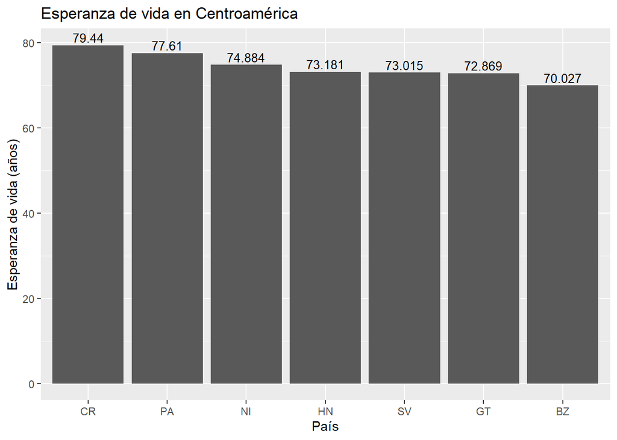

```r
 ggplot(centro_america, aes(x=reorder(iso_a2, -lifeExp), y=lifeExp)) +
   ggtitle("Esperanza de vida en Centroamérica") +
   xlab("País") +
   ylab("Esperanza de vida (años)") +
   geom_col() +
   geom_text(aes(label=lifeExp), vjust=-0.3, size=3.5)
```

### Ejercicio 7 (25%)

Con la función `plot()` del paquete [sf](https://cran.r-project.org/web/packages/sf/index.html), genere un [mapa de coropletas](https://en.wikipedia.org/wiki/Choropleth_map) con colores que reflejen la esperanza de vida de los siete países de Centroamérica. El mapa debe llevar un título.

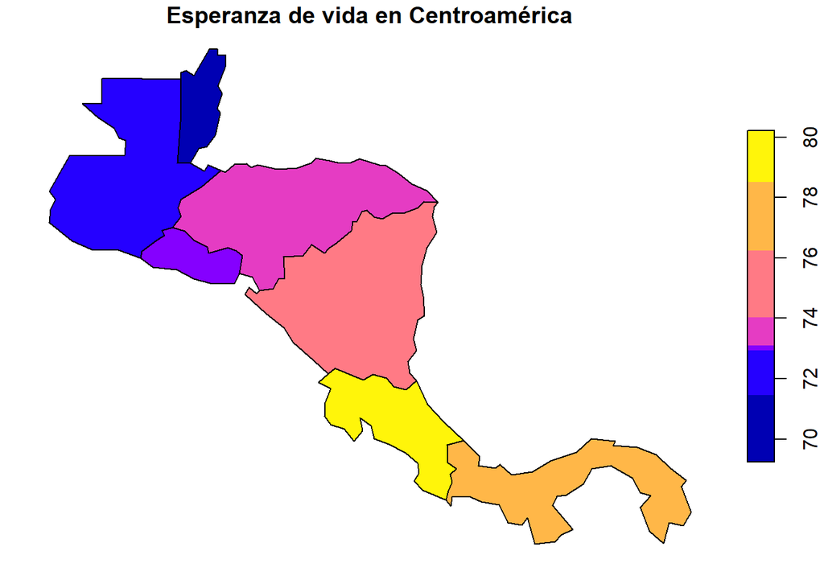

```r
plot(centro_america["lifeExp"], main="Esperanza de vida en Centroamérica")
```

### Ejercicio 8 (25%)

Extraiga en un nuevo data frame los países de Centroamérica con esperanza de vida mayor o igual a 74 años y genere el mapa de coropletas, con su título correspondiente.

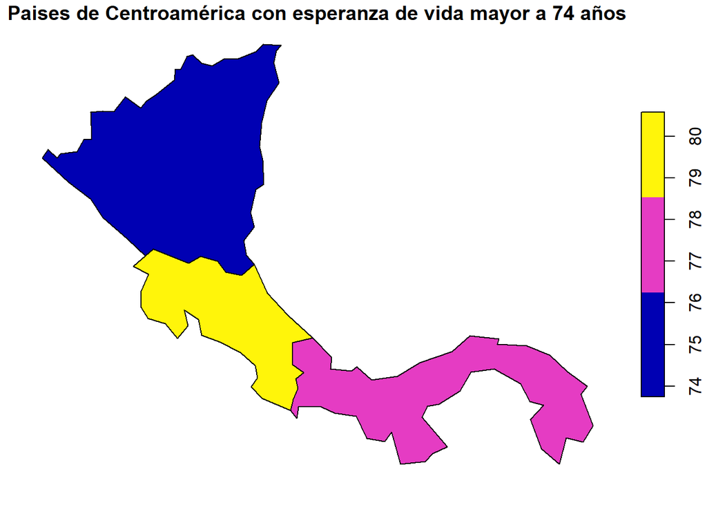

```r
centro_america_evida = centro_america[centro_america$lifeExp >= 74,]

plot(centro_america_evida["lifeExp"], main="Paises de Centroamérica con esperanza de vida mayor a 74 años")
```